# The Bayesian linear model

2020-08-21

# 1 Import the data

Import the `caterpillar.txt` file and undertake the following tasks below.

The $X$ variables are:

- $x_1$ altitude
- $x_2$ slope (in degrees)
- $x_3$ number of pines in the area
- $x_4$ height of the central tree
- $x_5$ diameter of the central tree
- $x_6$ index of the settlement density
- $x_7$ orientation of the area (from $1$ [southbound] to $2$)
- $x_8$ height of the dominant tree
- $x_9$ number of vegetation strata
- $x_{10}$ mix settlement index (from $1$ if not mixed to $2$ if mixed)

The response variable is the log transform of the average number of nests of caterpillars per tree in an area of 500 square meters (which corresponds to the last column in caterpillar).

```r
#set the working directory and put the data in that particular directory

require(knitr)
procession<-read.table("caterpillar.txt")

y<-log(procession$V11) #the response variable
X<-as.matrix(cbind(rep(1,33),procession[,1:10])) #add column of 1's for int
colnames(X)<-c("int","X1", "X2", "X3", "X4", "X5", "X6", "X7", "X8", "X9", "X10")
n<-length(y)
k<-dim(X)[2]
```

#Least squares regression

Plot $y$ against all of the explanatory variables and note any potential explanatory variables that should enter the regression model.

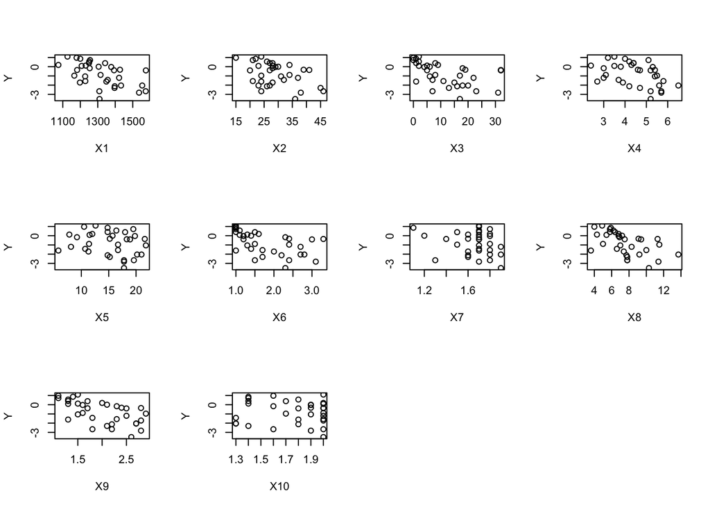

```r
#require(car)
#scatterplotMatrix(cbind(y,X[,-1]))

par(mfrow=c(3,4))
for (i in 1:10){
  plot(X[,i+1], y, main="", xlab=paste("X",i, sep=""), ylab="Y")
}
```

Perform ordinary least squares regression using the data set. Obtain the coefficient estimates, standard errors and t-values of the estimates. Comment on the model. Store the coefficient and residual variance objects as `betahat` and `sigmahat` respectively.

```r
fit1 <- lm(y~X[,-1])
summary(fit1)
```

```
##
## Call:
## lm(formula = y ~ X[, -1])
##
## Residuals:
##      Min       1Q   Median       3Q      Max
## -1.69898 -0.27317 -0.00036  0.32463  1.73050
##
## Coefficients:
##              Estimate Std. Error t value Pr(>|t|)
## (Intercept) 10.998412   3.060272   3.594  0.00161 **
## X[, -1]X1   -0.004431   0.001557  -2.846  0.00939 **
## X[, -1]X2   -0.053830   0.021900  -2.458  0.02232 *
## X[, -1]X3    0.067939   0.099472   0.683  0.50174
## X[, -1]X4   -1.293636   0.563811  -2.294  0.03168 *
## X[, -1]X5    0.231637   0.104378   2.219  0.03709 *
## X[, -1]X6   -0.356800   1.566464  -0.228  0.82193
## X[, -1]X7   -0.237469   1.006006  -0.236  0.81558
## X[, -1]X8    0.181060   0.236724   0.765  0.45248
## X[, -1]X9   -1.285316   0.864847  -1.486  0.15142
## X[, -1]X10  -0.433106   0.734869  -0.589  0.56162
## ---
## Signif. codes:  0 '***' 0.001 '**' 0.01 '*' 0.05 '.' 0.1 ' ' 1
##
## Residual standard error: 0.8293 on 22 degrees of freedom
## Multiple R-squared:  0.6949, Adjusted R-squared:  0.5563
## F-statistic: 5.012 on 10 and 22 DF,  p-value: 0.0007878
```

```r
#there are more stable ways of doing this!
betahat=solve(crossprod(X))%*%t(X)%*%y
#betahat

S2=t(y-X%*%betahat)%*%(y-X%*%betahat)
sigma2hat=S2/(n-k)
#sigma2hat
```

# 2 Conjugate prior distribution

Refer to the course slides.

Assume that we use a conjugate prior distribution for $\pmb \beta,\sigma$. Specifically assume that
$$\pmb \beta|\sigma^2\sim\mathscr{N}_{11}(\pmb 0_{11},\sigma^2 \pmb M^{-1})\,,$$
where $\pmb M = \frac{1}{c}\pmb I_{11}$ and
$$\sigma^2\sim \mathcal{IG}(a,b),\qquad a,b>0.$$
Set $c=0.1$, $a=2.1$ and $b=2$. Take note that in practice it is difficult to specify the make up of $\pmb M$.

## 2.1 Marginal posterior mean of $\pmb \beta| \pmb X, \pmb y$

Calculate the posterior mean of $\pmb \beta| \pmb X, \pmb y$ and compare it to the least squares estimator when $c$=0.1, 1, 10, 100, 1000 and 10000. **What do you notice?**

```r
a <- 2.1
b <- 2
c. <- 0.1

# caterpillar DATASET: POSTERIOR MEANS OF sigma2 FOR DIFFERENT c
# c=0.1

mu_beta_f <- function(c.){
  #calculate the posterior mean of beta|X, y
  M <- diag(11)/c.
  Mp.XtX <- M + crossprod(X)
  mu_beta <- solve(Mp.XtX)%*%t(X)%*%y
  return(mu_beta)
}

means_beta <- sapply(c(0.1, 1, 10, 100, 1000, 10000), mu_beta_f)
col.labels <- paste("c",c(0.1, 1, 10, 100, 1000, 10000), sep="")
kable(cbind(means_beta, betahat), col.names = c(col.labels,"ols"))
```

|  | c0.1 | c1 | c10 | c100 | c1000 | c10000 | ols |
| --- | --- | --- | --- | --- | --- | --- | --- |
| int | 0.1250665 | 0.9031402 | 4.7299374 | 9.6625925 | 10.8476481 | 10.9831393 | 10.9984124 |
| X1 | 0.0002143 | -0.0006940 | -0.0023508 | -0.0039978 | -0.0043821 | -0.0044259 | -0.0044308 |
| X2 | -0.0286251 | -0.0357283 | -0.0434187 | -0.0516387 | -0.0535831 | -0.0538050 | -0.0538301 |
| X3 | -0.0469848 | -0.0674681 | -0.0434940 | 0.0418260 | 0.0649557 | 0.0676367 | 0.0679394 |
| X4 | -0.2910841 | -0.9216907 | -1.1651344 | -1.2633097 | -1.2901440 | -1.2932819 | -1.2936364 |
| X5 | 0.0972168 | 0.2046857 | 0.2302547 | 0.2307182 | 0.2315195 | 0.2316247 | 0.2316368 |
| X6 | 0.0912524 | 0.5059915 | 0.7051560 | -0.0831806 | -0.3251885 | -0.3535897 | -0.3567997 |
| X7 | 0.0674373 | 0.2473412 | 0.0417623 | -0.1916826 | -0.2325447 | -0.2369728 | -0.2374691 |
| X8 | -0.0940622 | 0.0039880 | 0.0900850 | 0.1608481 | 0.1787607 | 0.1808270 | 0.1810602 |
| X9 | -0.0047583 | -0.1928632 | -0.8293998 | -1.2069266 | -1.2767524 | -1.2844516 | -1.2853161 |
| X10 | 0.2098335 | 0.5687691 | 0.3428464 | -0.2567007 | -0.4130267 | -0.4310697 | -0.4331055 |

From above it appears as if the value of $c$ can be used to provide a ‘weight’ to the prior information and the sample information respectively! i.e. As $c$ increases, the posterior mean tends to that of the ordinary least squares solution suggesting that a ‘large’ value of $c$ would place more ‘weight’ on the sample data than that of the prior information. **Does this make sense in this context?**

## 2.2 Marginal posterior mean of $\pmb \sigma^2| \pmb X, \pmb y$

Write a function named ‘post_var_s2’ to calculate the posterior mean of $\sigma^2|\pmb y, \pmb X$ when $c$=0.1, 1, 10, 100, 1000 and 10000. Compare these to the variances obtained when using ordinary least squares regression. *What do you notice if anything?* Compare the value of ${\hat{\sigma}}^2$ to that of $E(\sigma^2|\pmb y, \pmb X).$

```r
#Lets make a function (a bad one but it works)
post_var_s2 <- function(c.){
  #calculate the marginal posterior mean of s2
  M <- diag(11)/c.

  Mp.XtX <- M + crossprod(X)
  mu_beta <- solve(Mp.XtX)%*%t(X)%*%y

  A2 <- crossprod(y) - t(mu_beta)%*%Mp.XtX%*%mu_beta

  (2*b+A2)/(n + 2*a - 2)
}

means_var <- sapply(c(0.1, 1, 10, 100, 1000, 10000), post_var_s2)

kable(matrix(c(means_var, sigma2hat), nrow=1), col.names = c(col.labels,"ols"))
```

| c0.1 | c1 | c10 | c100 | c1000 | c10000 | ols |
| --- | --- | --- | --- | --- | --- | --- |
| 1.004425 | 0.8540642 | 0.697593 | 0.5746362 | 0.546958 | 0.5438159 | 0.687721 |

## 2.3 Lets look at $\pmb \beta| \pmb X, \pmb y$ again

Calculate the posterior mean and variance of $\beta_0| \pmb X, \pmb y$. Do the same for a few other explanatory variables. *What do you notice if anything?*

```r
post_mean_var_beta <- function(c., index){
  #calculate the marginal posterior mean and variance covariance
  #matrix of beta when using the congugate prior for
  #beta|sigma2 and sigma2
  #Below we report the results using the marginal posterior
  #distribution of beta|y , X
  #index = 1,2,..., or 11 in this case
  M <- diag(11)/c.

  Mp.XtX <- M + crossprod(X)
  mu_beta <- solve(Mp.XtX)%*%t(X)%*%y #correct!
  A2 <- 2*b + crossprod(y) - t(mu_beta)%*%Mp.XtX%*%mu_beta
  #cat("\n A2 = ", A2)
  beta_var <- solve(Mp.XtX)*A2[1]/(2*a+n) #from [beta| X, y]
  #beta_var <- solve(Mp.XtX)*post_var_s2(c.)[1] # from [beta| sigma, X, y]

  #the 'Bayesian core'
  #b_ols <- solve(crossprod(X))%*%t(X)%*%y
  #s2 <- crossprod(y-X%*%b_ols)
  #t1 <- 2*b + s2 + t(b_ols)%*%solve(solve(M)+solve(crossprod(X)))%*%b_ols
  #beta_var <- solve(M+crossprod(X))*t1[1]/(n+2*a)
  #cat("\n A2 book=", 2*b + s2 + t(b_ols)%*%solve(solve(M)+solve(crossprod(X)))%*%b_ols)

  c(mu_beta[index], beta_var[index, index])
}

mean_var_beta0<-t(sapply(c(0.1, 1, 10, 100, 1000, 10000), post_mean_var_beta, index=1))
colnames(mean_var_beta0)<-c("mean","var")
rownames(mean_var_beta0)<-c(0.1, 1, 10, 100, 1000, 10000)
mean_var_beta0
```

```
##             mean        var
## 0.1    0.1250665 0.09353413
## 1      0.9031402 0.73169329
## 10     4.7299374 3.68947932
## 100    9.6625925 6.46798526
## 1000  10.8476481 6.94721894
## 10000 10.9831393 6.99729396
```

Take note that
$$(\pmb y - \pmb X \hat{\pmb \beta})^T (\pmb y - \pmb X \hat{\pmb \beta}) + \hat{\pmb \beta}^T(\pmb M^{-1} + (\pmb X^T \pmb X)^{-1} )^{-1}\hat{\pmb \beta} = \pmb y^T \pmb y - \pmb \mu_{\pmb \beta}^T (\pmb M + \pmb X^T \pmb X) \pmb \mu_{\pmb \beta}$$
where
$$\pmb \mu_{\pmb \beta} = (\pmb M + \pmb X^T \pmb X)^{-1} \pmb X^T \pmb y.$$

## 2.4 Conclusions

From the above code you should realise that the specification of the prior distribution does matter! The value of $c$ does have a lasting impact on the resulting posterior inference. In future, we will assume that $c$ itself has a prior distribution and thereafter we will marginalise across $c$ to obtain a posterior distribution for $\pmb \beta, \sigma| \pmb y, \pmb X$ that does not depend on $c$.

# 3 Zellner’s G-prior

Repeat the above analysis using Zellner’s G-prior.